# Flights delays analysis part 1

# Business Question 1: Does the weather effectively influence the flights departure delays and which weather condition impact mostly?

In this first file I am going to concentrate on the first important business question which ask whether or not effectively weather does influence the length of flights delays.

```r
library(tidyverse)
library(GGally)
```

```r
flights_weather <- read_csv(here::here("cleaned_data/flights_weather.csv"))
```

```r
tight_flights_weather <- read_csv(here::here("cleaned_data/tight_flights_weather.csv"))
```

```r
skimr::skim(flights_weather)
```

```
── Data Summary ────────────────────────
                           Values
Name                       flights_weather
Number of rows             120955
Number of columns          20
_______________________
Column type frequency:
  character                7
  numeric                  12
  POSIXct                  1
________________________
Group variables            None
```

|  | skim_variable | n_missing | complete_rate | min | max | empty | n_unique | whitespace |
| --- | --- | --- | --- | --- | --- | --- | --- | --- |
| 1 | carrier | 0 | 1 | 2 | 2 | 0 | 12 | 0 |
| 2 | tailnum | 0 | 1 | 5 | 6 | 0 | 4021 | 0 |
| 3 | origin | 0 | 1 | 3 | 3 | 0 | 3 | 0 |
| 4 | dest | 0 | 1 | 3 | 3 | 0 | 109 | 0 |
| 5 | wind_speed_group | 0 | 1 | 5 | 7 | 0 | 4 | 0 |
| 6 | visib_group | 0 | 1 | 5 | 14 | 0 | 4 | 0 |
| 7 | wind_dir_group | 0 | 1 | 9 | 16 | 0 | 4 | 0 |

|  | skim_variable | n_missing | complete_rate | mean | sd | p0 | p25 | p50 | p75 | p100 | hist |
| --- | --- | --- | --- | --- | --- | --- | --- | --- | --- | --- | --- |
| 1 | dep_delay | 0 | 1.0000000 | 44.226423 | 71.458752 | 0.00 | 5.000000 | 19.00000 | 56.00000 | 1548.00000 | ▇▁▁▁▁ |
| 2 | arr_delay | 656 | 0.9945765 | 37.156610 | 73.899209 | -98.00 | -4.000000 | 16.00000 | 55.00000 | 1589.00000 | ▇▁▁▁▁ |
| 3 | flight | 0 | 1.0000000 | 1719.765855 | 1493.121606 | 1.00 | 509.000000 | 1338.00000 | 2240.00000 | 6988.00000 | ▇▅▁▂▁ |
| 4 | air_time | 656 | 0.9945765 | 166.238107 | 97.032710 | 20.00 | 103.000000 | 141.00000 | 213.00000 | 698.00000 | ▇▂▂▁▁ |
| 5 | distance | 0 | 1.0000000 | 1178.584283 | 757.209173 | 93.00 | 711.000000 | 1010.00000 | 1605.00000 | 4983.00000 | ▇▃▂▁▁ |
| 6 | wind_dir | 0 | 1.0000000 | 181.507692 | 111.849721 | 0.00 | 70.000000 | 200.00000 | 275.25000 | 360.00000 | ▇▃▆▇▆ |
| 7 | wind_speed | 0 | 1.0000000 | 9.350691 | 4.856185 | 0.00 | 5.753900 | 9.20624 | 12.65858 | 32.22184 | ▅▇▃▁▁ |
| 8 | wind_gust | 0 | 1.0000000 | 10.760589 | 5.588401 | 0.00 | 6.621473 | 10.59436 | 14.56724 | 37.08025 | ▅▇▃▁▁ |
| 9 | visib | 0 | 1.0000000 | 9.201514 | 2.087429 | 0.12 | 10.000000 | 10.00000 | 10.00000 | 10.00000 | ▁▁▁▁▇ |
| 10 | month | 0 | 1.0000000 | 6.265421 | 3.326950 | 1.00 | 4.000000 | 6.00000 | 9.00000 | 12.00000 | ▇▆▆▅▇ |

[output cut: 2 more lines]

|  | skim_variable | n_missing | complete_rate | min | max | median | n_unique |
| --- | --- | --- | --- | --- | --- | --- | --- |
| 1 | time_hour | 0 | 1 | 2017-01-01 08:00:00 | 2017-12-31 07:00:00 | 2017-06-20 10:00:00 | 6599 |

At first I need to specify that I decide to concentrate on the impact of weather on the length of delays and not on their number. This is because, the length of delays seems to me much more interesting, if I am in aim of comparing the delays to the weather conditions.

```r
flights_weather %>%
  filter(!is.na(arr_delay)) %>%
  summarise(cor(dep_delay, arr_delay))
```

| cor(dep_delay, arr_delay) |
| --- |
| 0.959594 |

**ASSUMPTION** First of all I notice that the arrival delays are strongly positive correlated with the departure delay. Since also the weather dataset refers only to the departure airports and for now I decided to ignore the arrival delays, I could consider to leave the `flights_weather` dataset as it is and to consider a smaller dataset to possibly join with the other that doesn’t contains the departure delays.

```r
flights_weather
```

| dep_delay | arr_delay | carrier | flight | tailnum | origin | dest | air_time | distance | time_hour | wind_dir | wind_speed | wind_gust | visib | month | day | hour | wind_speed_group | visib_group | wind_dir_group |
| --- | --- | --- | --- | --- | --- | --- | --- | --- | --- | --- | --- | --- | --- | --- | --- | --- | --- | --- | --- |
| 193 | 182 | UA | 1537 | N54711 | EWR | MIA | 148 | 1085 | 2017-10-01 21:00:00 | 10.0000 | 8.05546 | 9.270062 | 10 | 10 | 1 | 21 | 6 - 15 | greater than 8 | less than 100 |
| 733 | 708 | DL | 2925 | N882DN | JFK | SJU | 190 | 1598 | 2017-10-01 17:00:00 | 360.0000 | 8.05546 | 9.270062 | 10 | 10 | 1 | 17 | 6 - 15 | greater than 8 | greater than 300 |
| 0 | 5 | AA | 1572 | N3NSAA | JFK | PHX | 293 | 2153 | 2017-10-01 06:00:00 | 350.0000 | 17.26170 | 19.864419 | 10 | 10 | 1 | 6 | 16 - 25 | greater than 8 | greater than 300 |
| 33 | 33 | UA | 1483 | N502UA | EWR | SFO | 335 | 2565 | 2017-10-01 06:00:00 | 350.0000 | 16.11092 | 18.540125 | 10 | 10 | 1 | 6 | 16 - 25 | greater than 8 | greater than 300 |
| 1 | -6 | AA | 1508 | N3CWAA | JFK | CLT | 83 | 541 | 2017-10-01 06:00:00 | 350.0000 | 17.26170 | 19.864419 | 10 | 10 | 1 | 6 | 16 - 25 | greater than 8 | greater than 300 |
| 0 | -23 | UA | 475 | N61886 | EWR | ATL | 105 | 746 | 2017-10-01 07:00:00 | 360.0000 | 15.88076 | 18.275266 | 10 | 10 | 1 | 7 | 16 - 25 | greater than 8 | greater than 300 |
| 12 | -5 | DL | 424 | N624AG | JFK | LAX | 329 | 2475 | 2017-10-01 07:00:00 | 360.0000 | 14.96014 | 17.215830 | 10 | 10 | 1 | 7 | 6 - 15 | greater than 8 | greater than 300 |
| 5 | -14 | B6 | 885 | N296JB | JFK | RDU | 67 | 427 | 2017-10-01 07:00:00 | 360.0000 | 14.96014 | 17.215830 | 10 | 10 | 1 | 7 | 6 - 15 | greater than 8 | greater than 300 |
| 3 | -12 | WN | 5243 | N278WN | LGA | DAL | 188 | 1381 | 2017-10-01 07:00:00 | 360.0000 | 17.26170 | 19.864419 | 10 | 10 | 1 | 7 | 16 - 25 | greater than 8 | greater than 300 |
| 2 | -7 | UA | 497 | N2534U | EWR | SFO | 324 | 2565 | 2017-10-01 08:00:00 | 360.0000 | 14.48629 | 16.670532 | 10 | 10 | 1 | 8 | 6 - 15 | greater than 8 | greater than 300 |

[output cut: 990 more lines]

## Correlation coefficients

At first I will have a look of the correlation coefficients between the `dep_delay` and the weather features I selected.

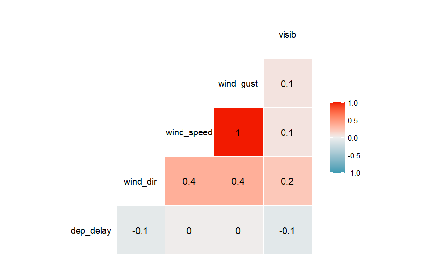

```r
flights_weather %>%
  select(dep_delay, wind_dir, wind_speed, wind_gust, visib) %>%
  ggcorr(label = TRUE)
```

At a first sight, looking at the correlation indexes, it seems that there is not so much interaction between `dep_delays` and `weather` conditions. However, since the dataset is really big, I will check these correlations in a more accurate way.

I also notice that there is a very strong correlation between `wind speed` and `wind gust speed` for this reason, I could consider to delete one of the two since their relationship is so strong.

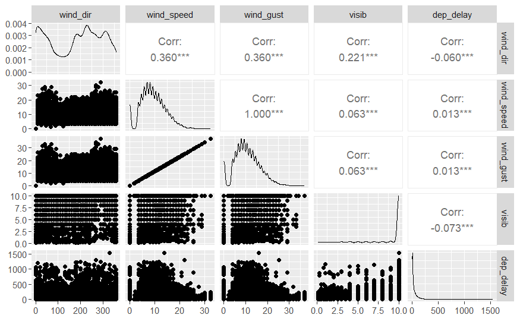

```r
flights_weather %>%
  select(wind_dir, wind_speed, wind_gust, visib, dep_delay) %>%
  ggpairs(progress = FALSE)
```

Here the correlation coefficients seems, even if still quite low, to give a more precise idea of the correlations. Foe example, looking at them, it seems interesting to analyse the relationship that `dep_delays` has with `wind_dir`, `wind_speed` and `visibility`.

Let’s have a more accurate view of how these three features are related with the ‘departure delays’.

# Wind Speed

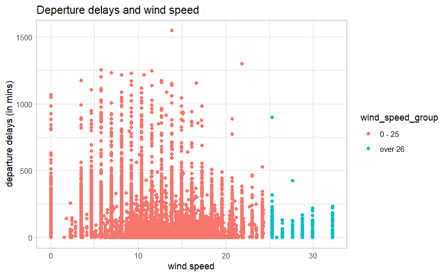

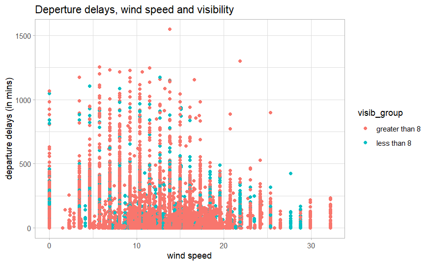

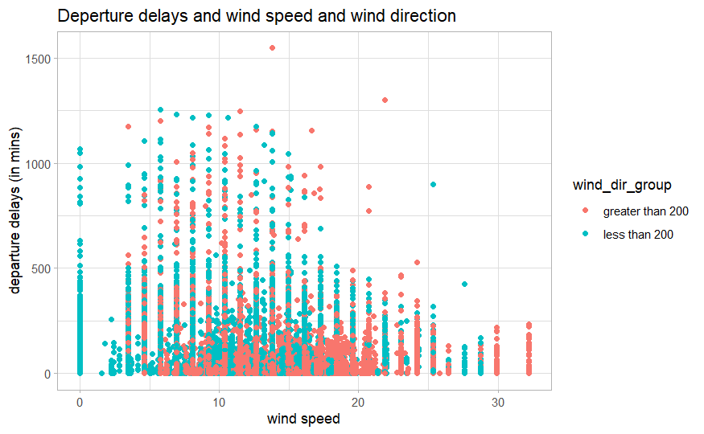

From this plot it seems that the `wind_speed` is more related maybe to the number of delays than to their length, but I am not actually interested in that, since I decided to concentrate on their length.

```r
model_speed_1 <- lm(dep_delay ~ wind_speed, flights_weather)
summary(model_speed_1)
```

```
Call:
lm(formula = dep_delay ~ wind_speed, data = flights_weather)

Residuals:
    Min      1Q  Median      3Q     Max
 -48.68  -39.53  -25.26   11.47 1502.91

Coefficients:
            Estimate Std. Error t value Pr(>|t|)
(Intercept) 42.40654    0.44577   95.13  < 2e-16 ***
wind_speed   0.19463    0.04231    4.60 4.22e-06 ***
---
Signif. codes:  0 ‘***’ 0.001 ‘**’ 0.01 ‘*’ 0.05 ‘.’ 0.1 ‘ ’ 1

Residual standard error: 71.45 on 120953 degrees of freedom
Multiple R-squared:  0.0001749, Adjusted R-squared:  0.0001667
F-statistic: 21.16 on 1 and 120953 DF,  p-value: 4.223e-06
```

```r
model_speed_2 <- lm(dep_delay ~ wind_speed_group, flights_weather)
summary(model_speed_2)
```

```
Call:
lm(formula = dep_delay ~ wind_speed_group, data = flights_weather)

Residuals:
    Min      1Q  Median      3Q     Max
 -54.57  -39.70  -25.08   11.30 1503.92

Coefficients:
                        Estimate Std. Error t value Pr(>|t|)
(Intercept)              43.6953     0.4751  91.978  < 2e-16 ***
wind_speed_group16 - 25   2.1191     0.7852   2.699  0.00696 **
wind_speed_group26 - 35  10.8699     3.8762   2.804  0.00504 **
wind_speed_group6 - 15    0.3863     0.5346   0.723  0.46996
---
Signif. codes:  0 ‘***’ 0.001 ‘**’ 0.01 ‘*’ 0.05 ‘.’ 0.1 ‘ ’ 1

Residual standard error: 71.46 on 120951 degrees of freedom
Multiple R-squared:  0.0001263, Adjusted R-squared:  0.0001015
F-statistic: 5.091 on 3 and 120951 DF,  p-value: 0.001598
```

From this model we can realise that splitting the wind_speed into groups can be useful for having a more accurate idea of how wind speed influence the departure delays. It would be also better to split it into simply two categories which seems to be more representative: ‘0 - 25’ mph and ‘over 26’ mph. I will do all the grouping modifications in the `tight_flights_weather` dataset.

```r
tight_flights_weather <- read_csv(here::here("cleaned_data/tight_flights_weather.csv"))
```

```r
model_speed_3 <- lm(dep_delay ~ wind_speed_group, tight_flights_weather)
summary(model_speed_3)
```

```
Call:
lm(formula = dep_delay ~ wind_speed_group, data = tight_flights_weather)

Residuals:
    Min      1Q  Median      3Q     Max
 -54.57  -39.20  -25.20   11.80 1503.80

Coefficients:
                        Estimate Std. Error t value Pr(>|t|)
(Intercept)              44.1968     0.2058 214.802  < 2e-16 ***
wind_speed_groupover 26  10.3684     3.8526   2.691  0.00712 **
---
Signif. codes:  0 ‘***’ 0.001 ‘**’ 0.01 ‘*’ 0.05 ‘.’ 0.1 ‘ ’ 1

Residual standard error: 71.46 on 120953 degrees of freedom
Multiple R-squared:  5.988e-05, Adjusted R-squared:  5.161e-05
F-statistic: 7.243 on 1 and 120953 DF,  p-value: 0.007119
```

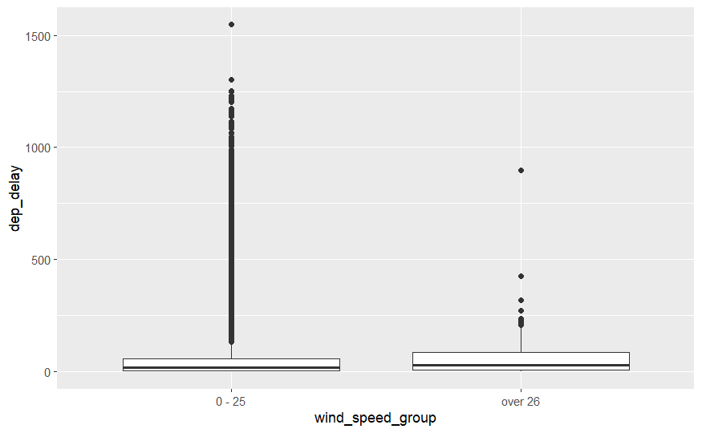

```r
tight_flights_weather %>%
  ggplot()+
  aes(x = wind_speed_group, y = dep_delay)+
  geom_boxplot()
```

# wind_dir

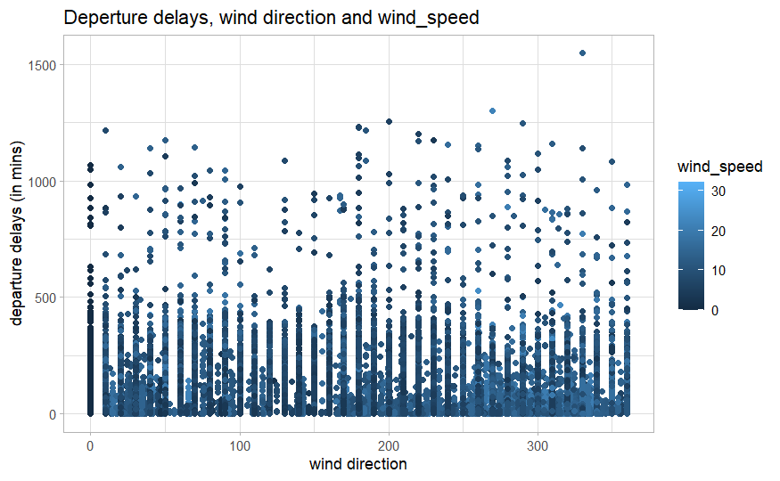

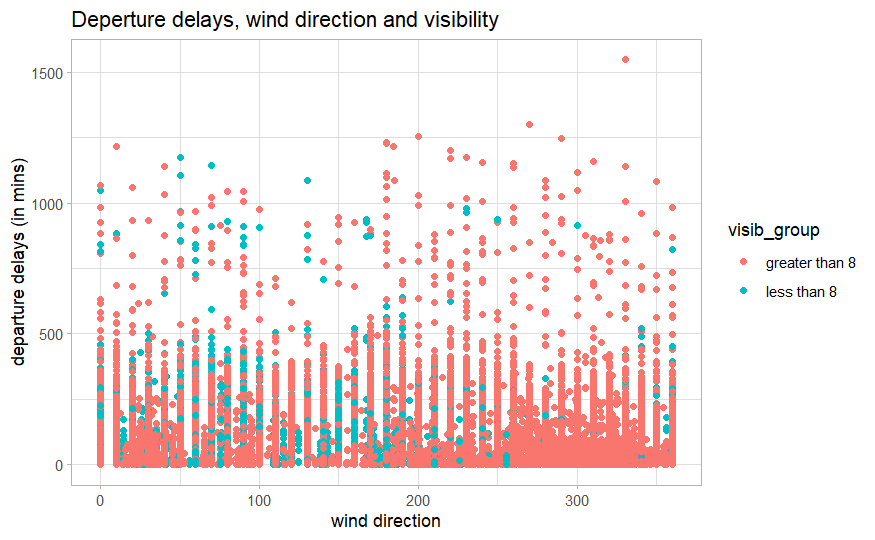

```r
model_dir_1 <- lm(dep_delay ~ wind_dir, flights_weather)
summary(model_dir_1)
```

```
Call:
lm(formula = dep_delay ~ wind_dir, data = flights_weather)

Residuals:
    Min      1Q  Median      3Q     Max
 -51.23  -38.36  -24.69   11.54 1509.50

Coefficients:
             Estimate Std. Error t value Pr(>|t|)
(Intercept) 51.230657   0.390941  131.04   <2e-16 ***
wind_dir    -0.038589   0.001834  -21.05   <2e-16 ***
---
Signif. codes:  0 ‘***’ 0.001 ‘**’ 0.01 ‘*’ 0.05 ‘.’ 0.1 ‘ ’ 1

Residual standard error: 71.33 on 120953 degrees of freedom
Multiple R-squared:  0.003648,  Adjusted R-squared:  0.00364
F-statistic: 442.9 on 1 and 120953 DF,  p-value: < 2.2e-16
```

Again, it doesn’t seems that, in general, `wind_dir` have significant impact on the delays, but let’s have a look of what happen splitting it into groups.

```r
model_dir_2 <- lm(dep_delay ~ wind_dir_group, flights_weather)
summary(model_dir_2)
```

```
Call:
lm(formula = dep_delay ~ wind_dir_group, data = flights_weather)

Residuals:
    Min      1Q  Median      3Q     Max
 -49.63  -37.63  -24.49   11.51 1511.28

Coefficients:
                               Estimate Std. Error t value Pr(>|t|)
(Intercept)                     48.0209     0.4545 105.664  < 2e-16 ***
wind_dir_group200 - 300         -7.5261     0.5809 -12.955  < 2e-16 ***
wind_dir_groupgreater than 300 -11.2960     0.6777 -16.669  < 2e-16 ***
wind_dir_groupless than 100      1.6079     0.5850   2.749  0.00599 **
---
Signif. codes:  0 ‘***’ 0.001 ‘**’ 0.01 ‘*’ 0.05 ‘.’ 0.1 ‘ ’ 1

Residual standard error: 71.28 on 120951 degrees of freedom
Multiple R-squared:  0.00505,   Adjusted R-squared:  0.005025
F-statistic: 204.6 on 3 and 120951 DF,  p-value: < 2.2e-16
```

Also in this case, it seems that there would be a better way of slitting `wind_dir`: `less than 200` and `great than 200`.

```r
model_dir_3 <- lm(dep_delay ~ wind_dir_group, tight_flights_weather)
summary(model_dir_3)
```

```
Call:
lm(formula = dep_delay ~ wind_dir_group, data = tight_flights_weather)

Residuals:
    Min      1Q  Median      3Q     Max
 -48.99  -38.21  -24.21   11.79 1508.79

Coefficients:
                            Estimate Std. Error t value Pr(>|t|)
(Intercept)                  39.2080     0.2937  133.49   <2e-16 ***
wind_dir_groupless than 200   9.7833     0.4101   23.86   <2e-16 ***
---
Signif. codes:  0 ‘***’ 0.001 ‘**’ 0.01 ‘*’ 0.05 ‘.’ 0.1 ‘ ’ 1

Residual standard error: 71.29 on 120953 degrees of freedom
Multiple R-squared:  0.004683,  Adjusted R-squared:  0.004675
F-statistic: 569.1 on 1 and 120953 DF,  p-value: < 2.2e-16
```

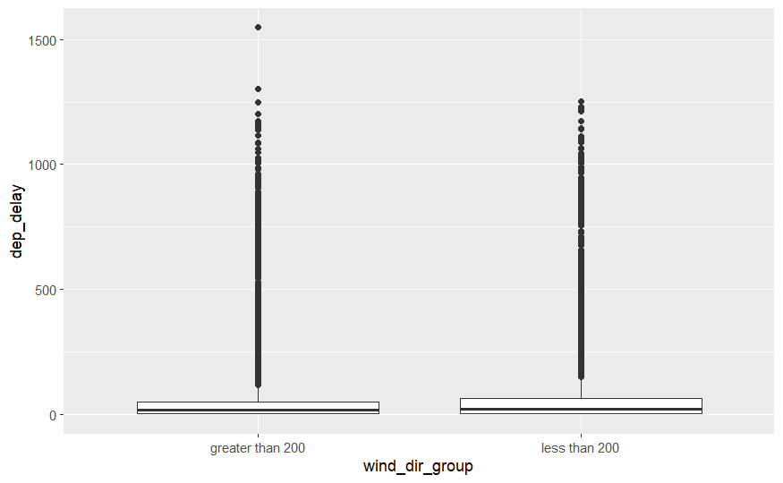

```r
tight_flights_weather %>%
  ggplot()+
  aes(x = wind_dir_group, y = dep_delay)+
  geom_boxplot()
```

# visib

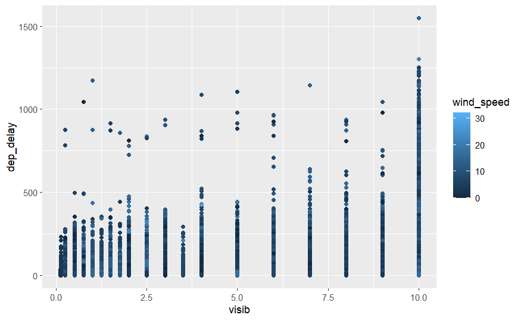

```r
model_visib_1 <- lm(dep_delay ~ visib, flights_weather)
summary(model_visib_1)
```

```
Call:
lm(formula = dep_delay ~ visib, data = flights_weather)

Residuals:
    Min      1Q  Median      3Q     Max
 -66.89  -38.23  -24.71   11.77 1505.77

Coefficients:
            Estimate Std. Error t value Pr(>|t|)
(Intercept) 67.18816    0.92626   72.54   <2e-16 ***
visib       -2.49543    0.09817  -25.42   <2e-16 ***
---
Signif. codes:  0 ‘***’ 0.001 ‘**’ 0.01 ‘*’ 0.05 ‘.’ 0.1 ‘ ’ 1

Residual standard error: 71.27 on 120953 degrees of freedom
Multiple R-squared:  0.005314,  Adjusted R-squared:  0.005306
F-statistic: 646.2 on 1 and 120953 DF,  p-value: < 2.2e-16
```

Same result as before. It doesn’t seem that, generally speaking, the visibility influence a lot flights delays. Let’s have a look of the grouped visibility.

```r
model_visib_2 <- lm(dep_delay ~ visib_group, flights_weather)
summary(model_visib_2)
```

```
Call:
lm(formula = dep_delay ~ visib_group, data = flights_weather)

Residuals:
    Min      1Q  Median      3Q     Max
 -61.85  -39.08  -25.08   11.77 1505.92

Coefficients:
                          Estimate Std. Error t value Pr(>|t|)
(Intercept)                55.8580     0.8434  66.231  < 2e-16 ***
visib_group6 - 8            0.3680     1.2122   0.304    0.761
visib_groupgreater than 8 -13.7786     0.8719 -15.803  < 2e-16 ***
visib_groupless than 2      5.9889     1.4895   4.021  5.8e-05 ***
---
Signif. codes:  0 ‘***’ 0.001 ‘**’ 0.01 ‘*’ 0.05 ‘.’ 0.1 ‘ ’ 1

Residual standard error: 71.26 on 120951 degrees of freedom
Multiple R-squared:  0.005593,  Adjusted R-squared:  0.005568
F-statistic: 226.8 on 3 and 120951 DF,  p-value: < 2.2e-16
```

```r
model_visib_1 <- lm(dep_delay ~ visib_group, tight_flights_weather)
summary(model_visib_1)
```

```
Call:
lm(formula = dep_delay ~ visib_group, data = tight_flights_weather)

Residuals:
    Min      1Q  Median      3Q     Max
 -57.17  -39.08  -25.08   11.83 1505.92

Coefficients:
                       Estimate Std. Error t value Pr(>|t|)
(Intercept)             42.0793     0.2212  190.19   <2e-16 ***
visib_groupless than 8  15.0946     0.5866   25.73   <2e-16 ***
---
Signif. codes:  0 ‘***’ 0.001 ‘**’ 0.01 ‘*’ 0.05 ‘.’ 0.1 ‘ ’ 1

Residual standard error: 71.26 on 120953 degrees of freedom
Multiple R-squared:  0.005444,  Adjusted R-squared:  0.005436
F-statistic: 662.1 on 1 and 120953 DF,  p-value: < 2.2e-16
```

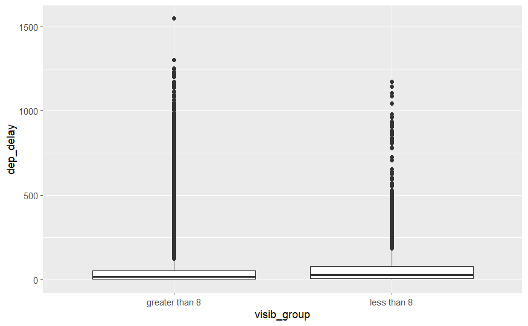

```r
tight_flights_weather %>%
  ggplot()+
  aes(x = visib_group, y = dep_delay)+
  geom_boxplot()
```

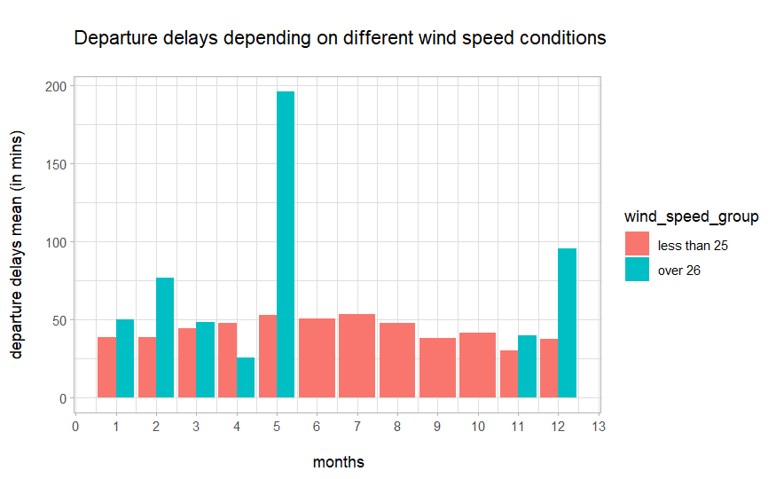

```r
tight_flights_weather %>%
  group_by(month, wind_speed_group) %>%
  summarise(mean_dep_delay = mean(dep_delay, na.rm = TRUE)) %>%
  ggplot()+
  aes(x = month, y = mean_dep_delay, fill = wind_speed_group)+
  geom_col(position = "dodge")+
  #geom_line() +
  theme_light()+
  labs(
    x = "\n months",
    y = "departure delays mean (in mins)\n",
    title = "\nDeparture delays depending on different wind speed conditions\n"
  )+
  scale_x_continuous(n.breaks = 12)
```

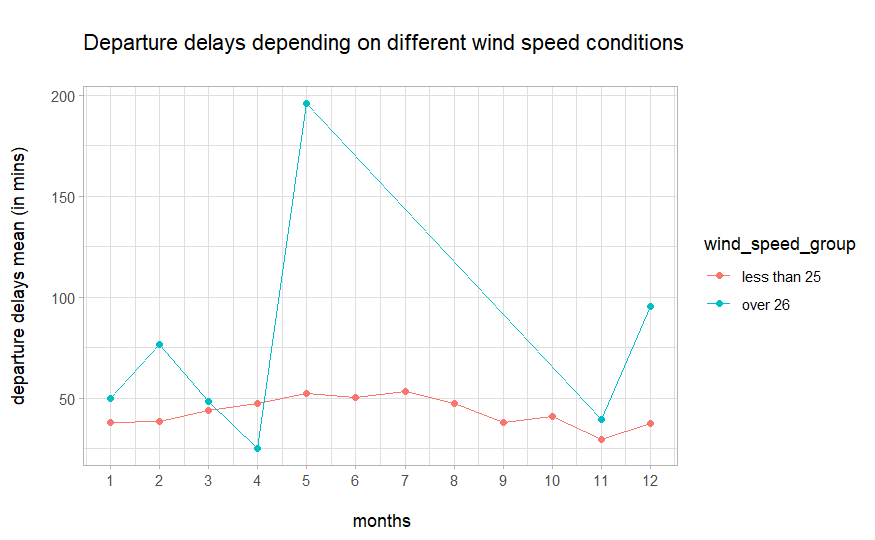

```r
tight_flights_weather %>%
  group_by(month, wind_speed_group) %>%
  summarise(mean_dep_delay = mean(dep_delay, na.rm = TRUE)) %>%
  ggplot()+
  aes(x = month, y = mean_dep_delay, colour = wind_speed_group)+
  #geom_col(position = "dodge")+
  geom_line()+
  geom_point()+
  labs(
    x = "\n months",
    y = "departure delays mean (in mins)\n",
    title = "\nDeparture delays depending on different wind speed conditions\n"
  )+
  theme_light()+
  scale_x_continuous(n.breaks = 12)
ggsave("wind_speed.png")
```

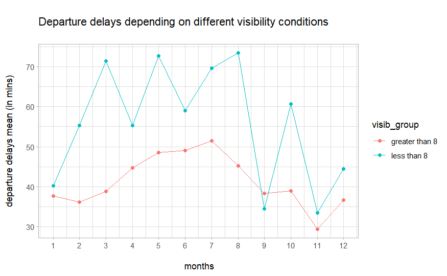

```r
tight_flights_weather %>%
  group_by(month, visib_group) %>%
  summarise(mean_dep_delay = mean(dep_delay, na.rm = TRUE)) %>%
  ggplot()+
  aes(x = month, y = mean_dep_delay, colour = visib_group)+
  #geom_col(position = "dodge")+
  geom_line()+
  geom_point()+
  theme_light()+
  labs(
    x = "\n months",
    y = "departure delays mean (in mins)\n",
    title = "\nDeparture delays depending on different visibility conditions\n"
  )+
  scale_x_continuous(n.breaks = 12)
ggsave("visib.png")
```

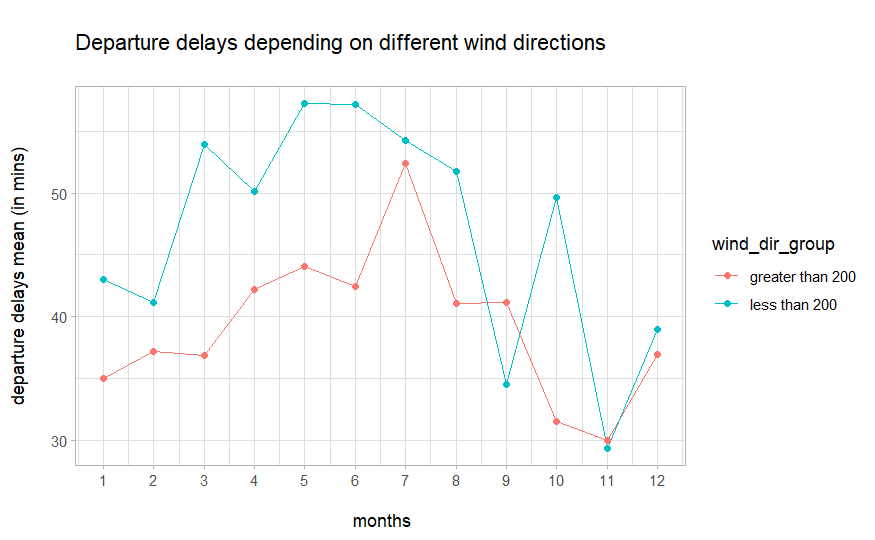

```r
tight_flights_weather %>%
  group_by(month, wind_dir_group) %>%
  summarise(mean_dep_delay = mean(dep_delay, na.rm = TRUE)) %>%
  ggplot()+
  aes(x = month, y = mean_dep_delay, colour = wind_dir_group)+
  #geom_col(position = "dodge")+
  geom_line()+
  geom_point()+
  theme_light()+
  labs(
    x = "\n months",
    y = "departure delays mean (in mins)\n",
    title = "\nDeparture delays depending on different wind directions\n"
  )+
  scale_x_continuous(n.breaks = 12)
ggsave("wind_dir.png")
```

## More models

```r
model_tot <- lm(dep_delay ~ wind_speed_group + visib_group + wind_dir_group, tight_flights_weather)
summary(model_tot)
```

```
Call:
lm(formula = dep_delay ~ wind_speed_group + visib_group + wind_dir_group,
    data = tight_flights_weather)

Residuals:
    Min      1Q  Median      3Q     Max
 -68.13  -37.46  -24.46   11.54 1509.54

Coefficients:
                            Estimate Std. Error t value Pr(>|t|)
(Intercept)                  38.4593     0.2955 130.143   <2e-16 ***
wind_speed_groupover 26       9.4843     3.8384   2.471   0.0135 *
visib_groupless than 8       12.4431     0.6031  20.632   <2e-16 ***
wind_dir_groupless than 200   7.7396     0.4214  18.366   <2e-16 ***
---
Signif. codes:  0 ‘***’ 0.001 ‘**’ 0.01 ‘*’ 0.05 ‘.’ 0.1 ‘ ’ 1

Residual standard error: 71.16 on 120951 degrees of freedom
Multiple R-squared:  0.008247,  Adjusted R-squared:  0.008223
F-statistic: 335.3 on 3 and 120951 DF,  p-value: < 2.2e-16
```

```r
summary(model_tot_2)
```

[output not shown]

```
Call:
lm(formula = dep_delay ~ wind_dir_group + visib_group, data = tight_flights_weather)

Residuals:
    Min      1Q  Median      3Q     Max
 -58.69  -37.49  -24.21   11.51 1509.51

Coefficients:
                            Estimate Std. Error t value Pr(>|t|)
(Intercept)                  38.4908     0.2952  130.37   <2e-16 ***
wind_dir_groupless than 200   7.7203     0.4213   18.32   <2e-16 ***
visib_groupless than 8       12.4817     0.6029   20.70   <2e-16 ***
---
Signif. codes:  0 ‘***’ 0.001 ‘**’ 0.01 ‘*’ 0.05 ‘.’ 0.1 ‘ ’ 1

Residual standard error: 71.17 on 120952 degrees of freedom
Multiple R-squared:  0.008197,  Adjusted R-squared:  0.008181
F-statistic: 499.8 on 2 and 120952 DF,  p-value: < 2.2e-16
```

```r
model_tot_3 <- lm(dep_delay ~ wind_dir_group + wind_speed_group, tight_flights_weather)
summary(model_tot_3)
```

```
Call:
lm(formula = dep_delay ~ wind_dir_group + wind_speed_group, data = tight_flights_weather)

Residuals:
    Min      1Q  Median      3Q     Max
 -60.50  -38.17  -24.17   11.83 1508.83

Coefficients:
                            Estimate Std. Error t value Pr(>|t|)
(Intercept)                  39.1671     0.2940 133.206  < 2e-16 ***
wind_dir_groupless than 200   9.7990     0.4101  23.892  < 2e-16 ***
wind_speed_groupover 26      11.5354     3.8439   3.001  0.00269 **
---
Signif. codes:  0 ‘***’ 0.001 ‘**’ 0.01 ‘*’ 0.05 ‘.’ 0.1 ‘ ’ 1

Residual standard error: 71.29 on 120952 degrees of freedom
Multiple R-squared:  0.004757,  Adjusted R-squared:  0.004741
F-statistic: 289.1 on 2 and 120952 DF,  p-value: < 2.2e-16
```